# Premier League Analysis

# Introduction

The English Football League system comprises of four leagues at different levels: the Premier League, EFL Championship, EFL League One, and EFL League Two. Teams in lower-level leagues can be promoted to the higher-level league if they finish in the top three or four positions, while teams in a higher-level league can be relegated to the lower-level league if they finish in the bottom three or four positions. For instance, Norwich City was promoted to the Premier League from the EFL Championship in 2021 as they were one of the top-performing teams in that league.

In this blog, our focus will be on the Premier League, which is the highest level of the English Football League system. The top four teams in the Premier League qualify for the UEFA Champions League, the highest level of club football competition in Europe, instead of getting promoted.

Our analysis will identify the highest-performing Premier League teams of the past decade and determine which team is the most dominant. Additionally, we will investigate if any of the high performing teams have been unlucky or lucky with the number of Premier League titles they have won in the past decade.

## **Methodology**

Our analysis utilized a host of R libraries such as **`RSQLite`**, **`tidyverse`**, **`igraph`**, **`ggraph`**, **`dplyr`**, **`ggnetwork`**, and **`Shiny Apps`** to facilitate data extraction, transformation, analysis, and visualization. More specific methodologies are mentioned throughout.

# Visualization and Analysis

## Clusters

In our first set of visualizations, we have performed a Cluster analysis to group teams based on the following performance metrics over the last 10 years: Average Goals Scored, Percentage Of Wins, and Average Goals Conceded. This is what is known as a k-means clustering analysis. The purpose of this analysis is to find if there are a group of high-performing teams in the Premier League.

**Determining the Number of Clusters (k)**: We used the elbow method to determine the optimal number of clusters (k) for the k-means algorithm. The elbow plot is a plot of the total within-cluster sum of squares against the number of clusters. The optimal k is usually chosen at the “elbow” point of the plot, which is where adding more clusters doesn’t significantly reduce the total within-cluster sum of squares. In this case, the optimal k is 3.

### Goals Scored v.s Percentage Wins

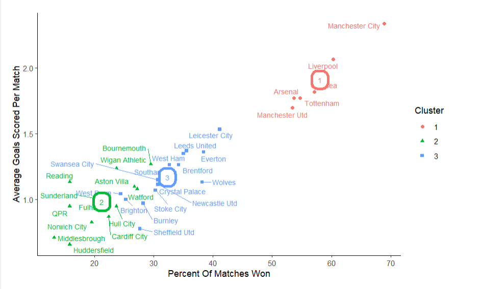

### Goals Conceded v.s Percentage Wins

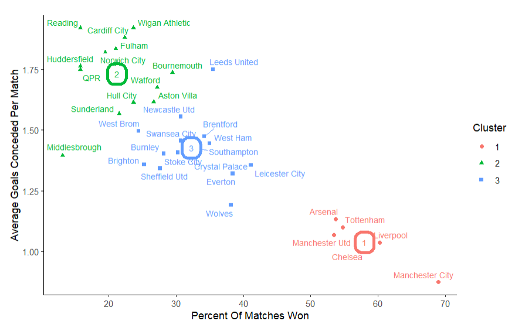

### Goals Scored v.s Goals Conceded

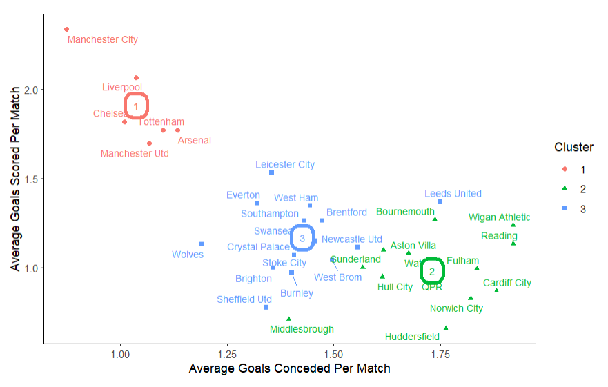

The plots of the cluster analysis show three groups. The group of high-performing teams, who are usually in the running to qualify for the Champions League, is Cluster 1. The group of low-performing teams, who usually fight for staying in the premier league, is Cluster 2. The group of medium-performing teams, who fight for a good mid-table spot in the premier league, is Cluster 3.

We will be focusing our analysis on Cluster 1 consisting of Manchester City, Manchester United, Liverpool, Chelsea, Arsenal, and Tottenham Hotspur. From all the Cluster visualizations we can see that Manchester City is a slight outlier in Cluster 1. It performed better than the other teams in Cluster 1. We will keep this in mind for all of our next visualizations.

## **Network Graph Analysis**

A network graph is a visual representation of the relationships between entities; in this case, football teams. Each team is represented as a node in the graph, and the edges (lines connecting the nodes) represent the goal differential between two teams. This provides a clear, intuitive way to understand the relationships and disparities among teams based on their past performance.

To make these network graphs we used data from openFootball.

**The Shiny app** allows users to interact with the network graph, selecting a specific team to view their goal differential with every other team they played against in the last ten years. This interactive feature allows users to explore data at a granular level, making the analysis more personal and engaging.

For example, when a user selects Manchester City, the app highlight the team’s node and its connections with other teams. The edge thickness could vary according to the goal difference, and the color could indicate a positive or negative differential. This way, users can easily perceive how well the selected team performed against others in terms of goal/Win difference.

[interactive chart not shown]

- The network graph shows a pretty dominant Manchester City Team as all the arrows show a positive goal difference, except two which show a neutral goal difference. Hence, Manchester City does not have a negative goal difference against any other premier league team.
- Manchester United also performed really well with negative goal differences against only Manchester City, and Tottenham Hotspur.
- Liverpool also did really well with negative goal differences against only Manchester City, and Manchester United.
- Tottenham Hotspurs had negative goal differences against four teams: Manchester City, Liverpool, Arsenal, and Chelsea.
- Chelsea had negative goal differences against three teams: Manchester City, Manchester United, and Liverpool.
- Arsenal had negative goal differences against five teams: Manchester City, Manchester United, Liverpool, Chelsea, and Brighton and Hove Albion.

Thus, from this visualization we can see that the high-performing teams only had negative goal differences against other high-performing teams, except Arsenal. From further inspection it can be seen that the goal difference between Arsenal and Brighton and Hove Albion is very small and as Brighton and Hove Albion only played in the Premier League for four out of the ten seasons this might not be as significant.

## Presentation of the Interactive Premier League Data Table

In our pursuit of providing an encompassing perspective on English Premier League’s last decade, we have curated an interactive table that manifests key statistics for all the teams that participated during this period. This dynamic platform offers the convenience of a broad overview and the specificity of individual team statistics, providing a versatile tool for both casual browsers and dedicated analysts.

The data fueling this interactive feature has been procured from a reputable source, FBref, and specifically, from their comprehensive compilation of the Premier League season statistics.

However, raw data, while rich in potential insights, can often be challenging to navigate and interpret. Recognizing this, we’ve employed robust data wrangling techniques to refine this raw data, focusing on relevant variables and ensuring that they are presented in an easily comprehensible format.

[interactive chart not shown]

[Data Science Premier League Table Shiny App](https://michaelp.shinyapps.io/table/)

Looking at the table by year, we can see that our high-performing teams are almost always the top six teams in the premier league.

Looking at the table by squad, we see that Manchester City has very high overall league goal differences, reaching +79 in the 2018 season.

## Decade-long Review of Premier League Winners through a Bar Graph

Our exploration concludes with a visual representation in the form of a bar graph, delineating the total points scored by each victorious Premier League team over the past decade. Each win in a season contributes three points to a team’s total, providing a straightforward metric to gauge the performance of a team over the season.

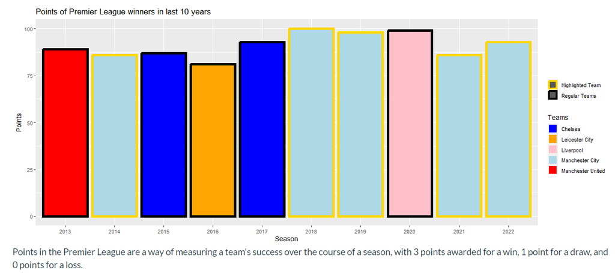

A glance at the bar graph unmistakably highlights Manchester City’s dominance. Their frequent ascents to the pinnacle of the league is reflected in their substantial points tally with their consistent high-level performance over the past decade.

However, while Manchester City’s success is indisputable, the graph reveals an essential truth of competitive sports - no team, no matter how dominant, is invincible. We see evidence of this in the occasional triumphs of other teams from the high-performing cluster, who have managed to break Manchester City’s winning streak and claim the league title for themselves.

There are also some other key takeaways from this graph. There are five different teams who won the Premier League. From all of our analysis before we might expect to see only the high-performing teams as the winners of the premier league. Surprisingly only four of the winning teams are among the initially selected high-performing teams. Leicester City won the 2016 premier league, even though it was not present in the cluster of high performing teams. On the other hand, Tottenham Hotspur and Arsenal failed to win any premier league season in the last decade even though they were present in the high-performing teams.

# Conclusion

Throughout our comprehensive data analysis, the compelling evidence of Manchester City’s dominance in English football has been unmistakable. They have consistently displayed superior performance metrics across various key parameters, including win percentage, average goals scored per match, and average goals conceded per match. This dominance is further emphasized in our network graph, where Manchester City frequently exhibits a positive goal differential against numerous competing teams. Thus, Manchester City is the most dominant Premier League team.

However, it’s important to note that dominance, while a significant factor, doesn’t always equate to winning the league. The volatile nature of football, replete with its unpredictabilities and chance events, means that a team’s dominance doesn’t provide an infallible prediction of their league-winning potential. The example of Leicester City winning the 2016 premier league, and Arsenal and Tottenham Hotspur being unable to win any league season in the past 10 years really highlights this point.

Moreover, winning a league involves a complex interplay of factors beyond just dominant performance in isolated matches. Aspects such as team morale, injuries, managerial strategies, and even the impact of external factors like fan support and weather conditions play crucial roles. Data science, while powerful, can only provide quantifiable insights and cannot account for these qualitative elements that can significantly sway a season’s outcomes.

In conclusion, while data science methodologies and tools like R programming, k-means clustering, and Shiny interactive applications provide valuable insights and illuminate patterns such as Manchester City’s dominance, they don’t deterministically predict outcomes like league victories. In the dynamic, multifaceted world of football, dominance is just one piece of the larger, intricate puzzle that decides the league champion. The beautiful game, much like data science, thrives on the balance of predictability and surprise, order and chaos.

# References

- Baumer, B. S., Kaplan, D. T., and Horton, N. J. (2021), *Modern Data Science with R* (2nd ed.), Boca Raton, FL: CRC Press.
- FBref. (2023). Premier League Statistics. FBref. https://fbref.com/en/comps/9/Premier-League-Stats
- My Football Facts. (2023). Premier League Winners List & History. My Football Facts. https://www.myfootballfacts.com/premier-league-winners/
- OpenFootball (2021). English Premier League, Seasons 2012-2021. https://github.com/openfootball/england
- tidyverse: Wickham et al. (2019). “Welcome to the tidyverse”. Journal of Open Source Software, 4(43), 1686. https://doi.org/10.21105/joss.01686
- ggplot2: Wickham (2016). ggplot2: Elegant Graphics for Data Analysis. Springer-Verlag New York. https://ggplot2.tidyverse.org/
- ggrepel: Slowikowski (2018). ggrepel: Repel overlapping text labels. https://github.com/slowkow/ggrepel
- broom: Robinson and Hayes (2020). broom: Convert Statistical Analysis Objects into Tidy Tibbles. https://broom.tidymodels.org/
- GGally: Schloerke et al. (2018). GGally: Extension to ggplot2. https://CRAN.R-project.org/package=GGally
- RSQLite: Wickham and Müller (2021). RSQLite: ‘SQLite’ Interface for R. https://CRAN.R-project.org/package=RSQLite
- igraph: Csardi and Nepusz (2006). The igraph software package for complex network research. InterJournal, Complex Systems 1695. https://igraph.org/
- ggraph: Pedersen (2021). ggraph: An implementation of Grammar of Graphics for Graphs and Networks. https://CRAN.R-project.org/package=ggraph
- dplyr: Wickham et al. (2021). dplyr: A Grammar of Data Manipulation. https://dplyr.tidyverse.org/
- ggnetwork: Csardi and Nepusz (2006). The igraph software package for complex network research. InterJournal, Complex Systems 1695. https://CRAN.R-project.org/package=ggnetwork
- tidygraph: Pedersen (2021). tidygraph: A Tidy API for Graph Manipulation. https://CRAN.R-project.org/package=tidygraph
- shiny: Chang et al. (2021). shiny: Web Application Framework for R. https://shiny.rstudio.com/
- shinythemes: Chang (2018). shinythemes: Themes for Shiny. https://CRAN.R-project.org/package=shinythemes
- DT: Xie et al. (2021). DT: A Wrapper of the JavaScript Library ‘DataTables’. https://CRAN.R-project.org/package=DT